# Feature Selection: An Exploration of Algorithm Performance

Jason Case, Abhishek Dugar, Daniel Nkuah, Khoa Tran

2024-07-30

## Introduction

What is feature selection? Why do we care?

- Feature selection is a crucial step in data preprocessing, especially in machine learning and statistical modeling. It involves selecting a subset of relevant features (variables, predictors) for building a model.
- It is important because it reduces the risk of overfitting and enhances the performance of machine learning models and pattern recognition systems.
- The goal/ objective of the study is to compare the performance of various feature selection methods on a variety of real-world datasets.

## Introduction: Early Techniques

Forward, backward, and stepwise variable selection in linear models.

- The forward method starts with no variables in the model, and we will add them one by one until no improvement is shown.
- Backward is when we start with all variables and remove the least significance iteratively.
- Stepwise selection combines both approaches, iteratively adding and removing variables to optimize the models performance.

## Introduction: Early Techniques

Univariate screening procedures (USP).

- USP represents an important milestone for feature selection.
- These methods involve evaluating each predictor variable individually to determine its relationship with the target variable. The process selects variables that meet a specific statistical threshold.
- While these methods are simple and quick to use, they often miss the complex connections between variables.

## Introduction: Modern Techniques

Classification of methods.

- The **filter** model selects features based on the general properties of the training data, independent of any learning algorithm, making it computationally efficient for large datasets.
- The **wrapper** model, on the other hand, uses a specific learning algorithm to evaluate and determine which features to keep, often leading to better performance but at a higher computational cost.
- **Embedded** methods perform feature selection during the model training process, integrating selection directly with learning.
- **Hybrid** methods combine the best aspects of filter and wrapper methods to achieve optimal performance with manageable computational complexity.

## Methods: Correlation - Based Feature Selection (CFS)

- Filter method.
- Uses the correlation coefficient to measure the relationship between each variable and the target, independently.
- Features that are highly correlated are considered important.

CFS’s feature subset evaluation function is:

$\text{Ms} = \frac{k\bar{\text{rcf}}}{\sqrt k + k(k - 1)\bar{\text{rff}}}$

## Methods: Recursive Feature Elimination (RFE)

- Wrapper method.
- Removes variables iteratively.

Steps:

1. Train the classifier.
2. compute the ranking criterion for all features.
3. remove the feature(s) with smallest ranking values.
4. Repeat until desired number of features selected.
- optimal subset of features - one that provides the highest accuracy.

## Methods: Least Absolute Shrinkage and Selection Operator (LASSO)

- Embedded method
- LASSO finds the coefficient of features
- Uses L1 Regularization to shrink coefficients to zero

The LASSO estimate is defined by the solution to the l1 optimization problem

minimize $\frac{\| Y - X\beta \|_2^2}{n}$ subject to $X \sum_{j=1}^{k} \|\beta_j\|_1 < t$

where $t$ is the upper bound for the sum of the coefficients.

## Methods: CFS & RFE

- Hybrid method.
- Combines filter and wrapper methods.

Step 1: Filtering using the correlation coefficient. (e.g. trim the “low hanging fruit”).

Step 2: Remove remaining variables iteratively using RFE.

## Analysis: Spambase Dataset

- 4601 instances of emails
- 57 features for classification tasks.
- Binary classification: email is spam (1) or not (0).
- 80/20 train/test split.
- Increased number of features by adding all $(\binom{57}{2} = 1,596)$ two-way interactions.

## Analysis: Spambase Dataset

Figure 1. Frequency of spam targets.

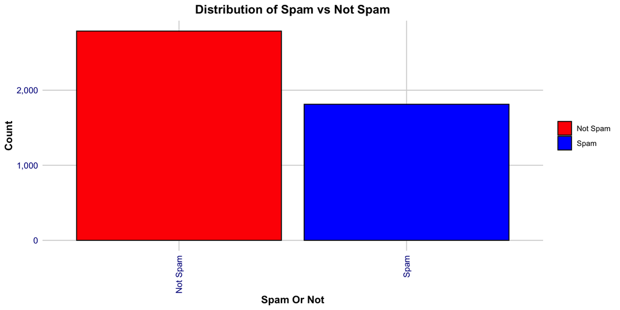

## Analysis: COVID-19 NLP Text Classification Dataset

- 45k tweets related to COVID-19, labeled for sentiment analysis.
- Five Sentiment label classes, ranging from extremely positive to extremely negative.
- Recoded to a binary classification task, positive (1) or negative (0).
- 33,444 (91%) training and 3,179 (9%) testing records after recoding.

## Analysis: COVID-19 NLP Text Classification Dataset

Figure 2. Frequency of sentiment targets.

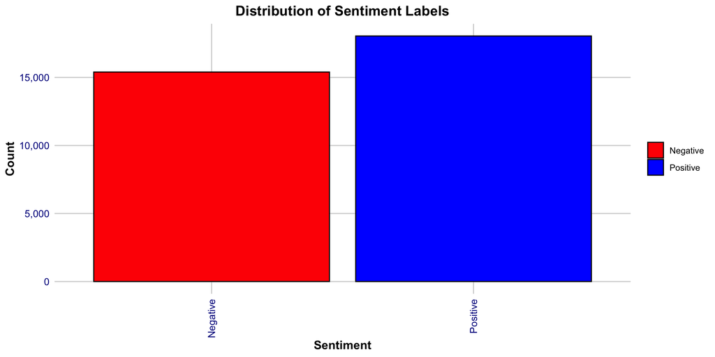

## Analysis: COVID-19 NLP Text Classification Dataset

“Bag of words”

- Text data converted into a matrix of word frequencies.
- Each row represents a document.
- Each column represents a unique word from the entire corpus.
- Large (several thousand variables), sparse (> 99% of values = 0) feature set.

## Statistical Modeling

Three metrics:

- **Accuracy** on the test set.
- Difference between accuracy on the training and test set (**overfitting**).
- Number of variables selected (model **complexity**).

5 models:

- **Baseline** Full logistics model with no feature selection.
- **CFS** Select best of 20 correlation thresholds using cross validation.
- **RFE** Select best of 20 sized subsets using cross validation.
- **LASSO** Select best penalty term using cross validation.
- **CFS + RFE** Remove 20% of variables with lowest correlation, Select best of 20 sized subsets using cross validation.

## Results: Spambase Dataset

Table 1. Results of spam classification task.

| Method | Number of Features | Test Accuracy Score | Accuracy Decrease from Train |
| --- | --- | --- | --- |
| Baseline | 1653 | 0.915 | 0.070 |
| CFS | 126 | 0.936 | -0.004 |
| RFE | 1144 | 0.911 | 0.067 |
| LASSO | 50 | 0.903 | -0.006 |
| CFS + RFE | 683 | 0.920 | 0.045 |

## Results: COVID-19 NLP Text Classification Dataset

Table 2. Results of sentiment classification task.

| Method | Number of Features | Test Accuracy Score | Accuracy Decrease from Train |
| --- | --- | --- | --- |
| Baseline | 4820 | 0.846 | 0.097 |
| CFS | 1449 | 0.868 | 0.042 |
| RFE | 2980 | 0.863 | 0.059 |
| LASSO | 4472 | 0.880 | 0.045 |
| CFS + RFE | 2672 | 0.778 | 0.088 |

## Results: Observations per Feature

- Decreased the ratio of observations per feature.
- Selected 10% of records for spam task.
- Increased features for sentiment task by decreasing threshold for “rare” words from 10 to 2.
- Ran analysis on new datasets.
- Reported overfitting as a function of observations per feature.

## Results: Observations per Feature

Figure 3. Plot of overfitting as a function of observations per feature.

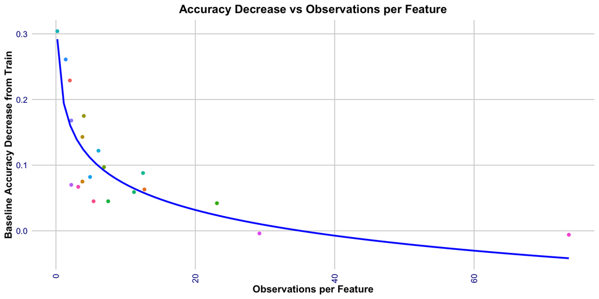

## Conclusion

Is feature selection still relevant?

- Large “big data” datasets have a high ratio of observations to features, even for thousands of features.
- Models still need to find an optimum solution; a smaller feature space means less exploration is needed to find the best model.
- Pragmatic constraints: Documentation and dependencies.

**Thanks for listening!**